# Healthcare-Intervention-ROI-model

Pattaraporn Chutipongvivet

2025-04-23

## Executive Summary

**Diabetes presents a significant cost burden to insurers, with an average claim of $12,022* per patient annually. By applying machine learning models to early identify high-risk individuals, insurers can intervene proactively — reducing claim severity, improving patient outcomes, and boosting ROI.**

We evaluated six ML models and one ensemble (stacked) model using performance and financial metrics. The stacked model emerged as the best strategy for maximizing per-member savings while maintaining high sensitivity.

**Business Impact**: The stacked model can save up to **$1,294.30 per person** and deliver an ROI of **1438%** through targeted interventions.

Key recommendations: - Deploy a predictive model to identify high-risk individuals early. - Prioritize outreach to true positives to reduce long-term claims. - Reinvest part of savings in patient education and tech integration.

This model offers a scalable, cost-effective solution for insurers facing rising chronic disease costs.

- Reference : https://pubmed.ncbi.nlm.nih.gov/37909353/

## Introduction

This project applies predictive modeling to forecast diabetes risk and quantify financial impact. We focus on enabling targeted preventive action to reduce insurer claim liabilities.

### Get Data

We imported and reviewed the diabetes dataset, ensuring it was ready for modeling. Summary statistics confirm balanced variable types and clean formatting.

```r
# Load libraries
library(caret)
library(C50)
library(randomForest)
library(neuralnet)
library(kernlab)
```

```r
library(class)
library(knitr)
library(kableExtra)
library(ggplot2)
library(scales)
library(magrittr)
```

```r
diabetes <- read.csv("diabetes.csv")
str(diabetes)
```

```
## 'data.frame':    768 obs. of  9 variables:
##  $ Pregnancies             : int  6 1 8 1 0 5 3 10 2 8 ...
##  $ Glucose                 : int  148 85 183 89 137 116 78 115 197 125 ...
##  $ BloodPressure           : int  72 66 64 66 40 74 50 0 70 96 ...
##  $ SkinThickness           : int  35 29 0 23 35 0 32 0 45 0 ...
##  $ Insulin                 : int  0 0 0 94 168 0 88 0 543 0 ...
##  $ BMI                     : num  33.6 26.6 23.3 28.1 43.1 25.6 31 35.3 30.5 0 ...
##  $ DiabetesPedigreeFunction: num  0.627 0.351 0.672 0.167 2.288 ...
##  $ Age                     : int  50 31 32 21 33 30 26 29 53 54 ...
##  $ Outcome                 : int  1 0 1 0 1 0 1 0 1 1 ...
```

```r
summary(diabetes)
```

```
##   Pregnancies        Glucose      BloodPressure    SkinThickness
##  Min.   : 0.000   Min.   :  0.0   Min.   :  0.00   Min.   : 0.00
##  1st Qu.: 1.000   1st Qu.: 99.0   1st Qu.: 62.00   1st Qu.: 0.00
##  Median : 3.000   Median :117.0   Median : 72.00   Median :23.00
##  Mean   : 3.845   Mean   :120.9   Mean   : 69.11   Mean   :20.54
##  3rd Qu.: 6.000   3rd Qu.:140.2   3rd Qu.: 80.00   3rd Qu.:32.00
##  Max.   :17.000   Max.   :199.0   Max.   :122.00   Max.   :99.00
##     Insulin           BMI        DiabetesPedigreeFunction      Age
##  Min.   :  0.0   Min.   : 0.00   Min.   :0.0780           Min.   :21.00
##  1st Qu.:  0.0   1st Qu.:27.30   1st Qu.:0.2437           1st Qu.:24.00
##  Median : 30.5   Median :32.00   Median :0.3725           Median :29.00
##  Mean   : 79.8   Mean   :31.99   Mean   :0.4719           Mean   :33.24
##  3rd Qu.:127.2   3rd Qu.:36.60   3rd Qu.:0.6262           3rd Qu.:41.00
##  Max.   :846.0   Max.   :67.10   Max.   :2.4200           Max.   :81.00
##     Outcome
##  Min.   :0.000
##  1st Qu.:0.000
##  Median :0.000
##  Mean   :0.349
##  3rd Qu.:1.000
##  Max.   :1.000
```

## Scale Data

Let’s scale the data since there is a difference between how certain variables are recorded. For example, pregnancies are all below 20 while blood pressure can range up to 122. Scaling this ensures faster and more stable fitting.

```r
scaled_predictors <- scale(diabetes[, names(diabetes) != "Outcome"])
diabetes_scaled <- data.frame(scaled_predictors, Outcome = diabetes$Outcome)
summary(diabetes_scaled)
```

```
##   Pregnancies         Glucose        BloodPressure     SkinThickness
##  Min.   :-1.1411   Min.   :-3.7812   Min.   :-3.5703   Min.   :-1.2874
##  1st Qu.:-0.8443   1st Qu.:-0.6848   1st Qu.:-0.3671   1st Qu.:-1.2874
##  Median :-0.2508   Median :-0.1218   Median : 0.1495   Median : 0.1544
##  Mean   : 0.0000   Mean   : 0.0000   Mean   : 0.0000   Mean   : 0.0000
##  3rd Qu.: 0.6395   3rd Qu.: 0.6054   3rd Qu.: 0.5629   3rd Qu.: 0.7186
##  Max.   : 3.9040   Max.   : 2.4429   Max.   : 2.7327   Max.   : 4.9187
##     Insulin             BMI            DiabetesPedigreeFunction
##  Min.   :-0.6924   Min.   :-4.057829   Min.   :-1.1888
##  1st Qu.:-0.6924   1st Qu.:-0.595191   1st Qu.:-0.6885
##  Median :-0.4278   Median : 0.000941   Median :-0.2999
##  Mean   : 0.0000   Mean   : 0.000000   Mean   : 0.0000
##  3rd Qu.: 0.4117   3rd Qu.: 0.584390   3rd Qu.: 0.4659
##  Max.   : 6.6485   Max.   : 4.452906   Max.   : 5.8797
##       Age             Outcome
##  Min.   :-1.0409   Min.   :0.000
##  1st Qu.:-0.7858   1st Qu.:0.000
##  Median :-0.3606   Median :0.000
##  Mean   : 0.0000   Mean   :0.349
##  3rd Qu.: 0.6598   3rd Qu.:1.000
##  Max.   : 4.0611   Max.   :1.000
```

## Split

This dataset is large enough to allow a 50-50 train-test split. To maintain class balance, we applied stratified sampling to preserve the proportion of outcome values across both sets.

```r
set.seed(12345)
train_index <- createDataPartition(diabetes_scaled$Outcome, p = 0.5, list = FALSE)

diabetes_train <- diabetes_scaled[train_index, ]
diabetes_test <- diabetes_scaled[-train_index, ]

prop.table(table(diabetes_train$Outcome))
```

```
##
##         0         1
## 0.6484375 0.3515625
```

```r
prop.table(table(diabetes_test$Outcome))
```

```
##
##         0         1
## 0.6536458 0.3463542
```

## Logistic Regression

```r
set.seed(12345)
test_rows <- sample(1:nrow(diabetes),0.5*nrow(diabetes))

DMLR <- glm(Outcome~., data=diabetes_train, family="binomial")
summary(DMLR)
```

```
##
## Call:
## glm(formula = Outcome ~ ., family = "binomial", data = diabetes_train)
##
## Coefficients:
##                          Estimate Std. Error z value Pr(>|z|)
## (Intercept)               -0.8065     0.1366  -5.906 3.50e-09 ***
## Pregnancies                0.5180     0.1559   3.323 0.000889 ***
## Glucose                    0.9888     0.1617   6.116 9.57e-10 ***
## BloodPressure             -0.3378     0.1525  -2.215 0.026772 *
## SkinThickness              0.1012     0.1564   0.647 0.517836
## Insulin                   -0.1744     0.1357  -1.285 0.198770
## BMI                        0.6336     0.1632   3.882 0.000104 ***
## DiabetesPedigreeFunction   0.1708     0.1354   1.262 0.206914
## Age                        0.4445     0.1650   2.694 0.007055 **
## ---
## Signif. codes:  0 '***' 0.001 '**' 0.01 '*' 0.05 '.' 0.1 ' ' 1
##
## (Dispersion parameter for binomial family taken to be 1)
##
##     Null deviance: 497.98  on 383  degrees of freedom
## Residual deviance: 364.82  on 375  degrees of freedom
## AIC: 382.82
##
## Number of Fisher Scoring iterations: 5
```

```r
LRpred <- predict(DMLR,diabetes_test,type="response")
summary(LRpred)
```

```
##     Min.  1st Qu.   Median     Mean  3rd Qu.     Max.
## 0.002781 0.126239 0.268885 0.369732 0.607065 0.981277
```

```r
LRbin <- ifelse(LRpred>=0.5,1,0)

library(caret)
confusionMatrix(as.factor(LRbin),
                as.factor(diabetes_test$Outcome), positive="1")
```

```
## Confusion Matrix and Statistics
##
##           Reference
## Prediction   0   1
##          0 209  48
##          1  42  85
##
##                Accuracy : 0.7656
##                  95% CI : (0.72, 0.8071)
##     No Information Rate : 0.6536
##     P-Value [Acc > NIR] : 1.312e-06
##
##                   Kappa : 0.4768
##
##  Mcnemar's Test P-Value : 0.5982
##
##             Sensitivity : 0.6391
##             Specificity : 0.8327
##          Pos Pred Value : 0.6693
##          Neg Pred Value : 0.8132
##              Prevalence : 0.3464
##          Detection Rate : 0.2214
##    Detection Prevalence : 0.3307
##       Balanced Accuracy : 0.7359
##
##        'Positive' Class : 1
##
```

## Decision Tree

The decision tree achieved strong interpretability and moderate accuracy. However, it underperformed in financial metrics compared to ensemble approaches.

[figure not shown]

```r
library(C50)

# Train the decision tree
tree_model <- C5.0(as.factor(Outcome) ~ ., data = diabetes_train)

plot(tree_model)
```

### DT Prediction

```r
tree_prob <- predict(tree_model, diabetes_test, type = "prob")[, 2]
tree_pred <- ifelse(tree_prob > 0.5, "1", "0")
confusionMatrix(as.factor(tree_pred), as.factor(diabetes_test$Outcome), positive = "1")
```

```
## Confusion Matrix and Statistics
##
##           Reference
## Prediction   0   1
##          0 189  55
##          1  62  78
##
##                Accuracy : 0.6953
##                  95% CI : (0.6466, 0.741)
##     No Information Rate : 0.6536
##     P-Value [Acc > NIR] : 0.04716
##
##                   Kappa : 0.3353
##
##  Mcnemar's Test P-Value : 0.57910
##
##             Sensitivity : 0.5865
##             Specificity : 0.7530
##          Pos Pred Value : 0.5571
##          Neg Pred Value : 0.7746
##              Prevalence : 0.3464
##          Detection Rate : 0.2031
##    Detection Prevalence : 0.3646
##       Balanced Accuracy : 0.6697
##
##        'Positive' Class : 1
##
```

## Random Forest

Random forest improved overall accuracy and stability via aggregation of multiple decision trees. Its performance offered good savings and ROI potential.

```r
diabetesRF <- randomForest(Outcome ~ ., data = diabetes_train)
```

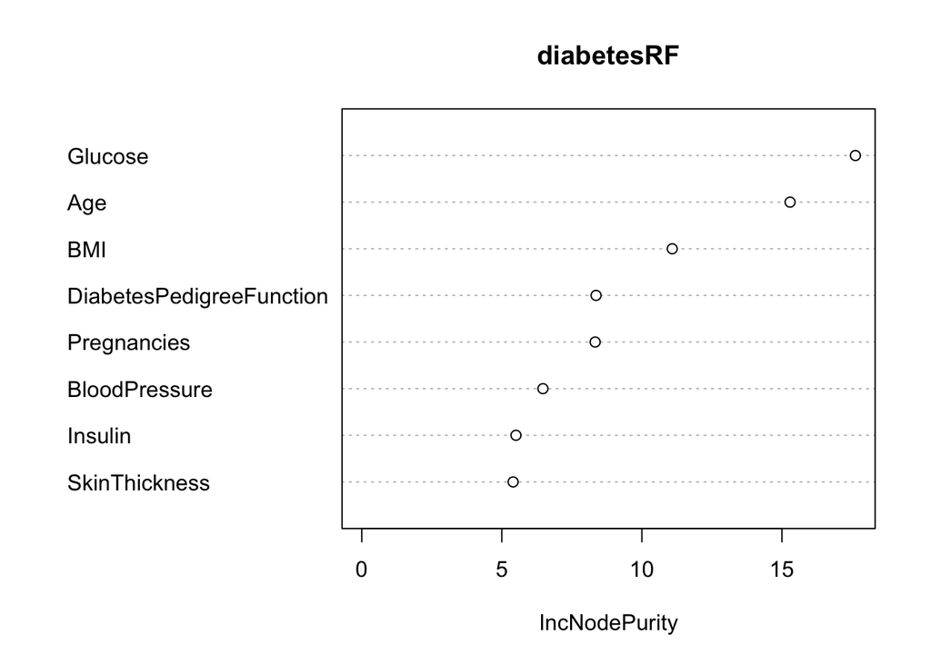

```r
randomForest::varImpPlot(diabetesRF)
```

```r
RFpred <- predict(diabetesRF, diabetes_test)
RFbin <- ifelse(RFpred >0.5, 1,0)


library(caret)
confusionMatrix(as.factor(RFbin),
                as.factor(diabetes_test$Outcome), positive = "1")
```

```
## Confusion Matrix and Statistics
##
##           Reference
## Prediction   0   1
##          0 206  50
##          1  45  83
##
##                Accuracy : 0.7526
##                  95% CI : (0.7063, 0.795)
##     No Information Rate : 0.6536
##     P-Value [Acc > NIR] : 1.845e-05
##
##                   Kappa : 0.4487
##
##  Mcnemar's Test P-Value : 0.6815
##
##             Sensitivity : 0.6241
##             Specificity : 0.8207
##          Pos Pred Value : 0.6484
##          Neg Pred Value : 0.8047
##              Prevalence : 0.3464
##          Detection Rate : 0.2161
##    Detection Prevalence : 0.3333
##       Balanced Accuracy : 0.7224
##
##        'Positive' Class : 1
##
```

## Support Vector Machine (SVM)

Support Vector Machine delivered solid specificity but lower sensitivity. As a result, fewer high-risk individuals were flagged, limiting cost savings.

```r
svmlinear <- ksvm(as.factor(Outcome) ~., data = diabetes_train, kernal = "linear")

svmpred <- predict(svmlinear, diabetes_test)

confusionMatrix(as.factor(svmpred),
                as.factor(diabetes_test$Outcome), positive = "1")
```

```
## Confusion Matrix and Statistics
##
##           Reference
## Prediction   0   1
##          0 214  63
##          1  37  70
##
##                Accuracy : 0.7396
##                  95% CI : (0.6926, 0.7828)
##     No Information Rate : 0.6536
##     P-Value [Acc > NIR] : 0.0001855
##
##                   Kappa : 0.3972
##
##  Mcnemar's Test P-Value : 0.0124193
##
##             Sensitivity : 0.5263
##             Specificity : 0.8526
##          Pos Pred Value : 0.6542
##          Neg Pred Value : 0.7726
##              Prevalence : 0.3464
##          Detection Rate : 0.1823
##    Detection Prevalence : 0.2786
##       Balanced Accuracy : 0.6895
##
##        'Positive' Class : 1
##
```

## The artificial neural network (ANN)

The artificial neural network exhibited signs of overfitting despite tuning. Its low sensitivity resulted in under-detection of true cases.

```r
m1 <- neuralnet(Outcome ~., data = diabetes_train,
                hidden = c(8,4),  #more layers/larger width resulted in lower accuracy - Overfitting
                threshold = 0.005,
                stepmax = 1e8,
                lifesign = "full")
```

[output not shown]

[output cut: 390 more lines]

```r
plot(m1)
```

### ANN Prediction

```r
ANNpred <- predict(m1, diabetes_test)
summary(ANNpred)
```

```
##        V1
##  Min.   :-1.03120
##  1st Qu.: 0.02098
##  Median : 0.05910
##  Mean   : 0.31591
##  3rd Qu.: 0.87740
##  Max.   : 1.79503
```

```r
ANNpredbin <- ifelse(ANNpred>0.5,1,0)

library(caret)
confusionMatrix(as.factor(ANNpredbin),as.factor(diabetes_test$Outcome), positive = "1")
```

```
## Confusion Matrix and Statistics
##
##           Reference
## Prediction   0   1
##          0 189  72
##          1  62  61
##
##                Accuracy : 0.651
##                  95% CI : (0.601, 0.6987)
##     No Information Rate : 0.6536
##     P-Value [Acc > NIR] : 0.5660
##
##                   Kappa : 0.2154
##
##  Mcnemar's Test P-Value : 0.4369
##
##             Sensitivity : 0.4586
##             Specificity : 0.7530
##          Pos Pred Value : 0.4959
##          Neg Pred Value : 0.7241
##              Prevalence : 0.3464
##          Detection Rate : 0.1589
##    Detection Prevalence : 0.3203
##       Balanced Accuracy : 0.6058
##
##        'Positive' Class : 1
##
```

## K-Nearest Neighbors (KNN)

```r
diabetes_test_dummy <- as.data.frame(model.matrix(~. -1, data = diabetes_test))
diabetes_train_dummy <- as.data.frame(model.matrix(~. -1, data = diabetes_train))

diabetes_test_Outcome <- diabetes_test_dummy$Outcome
diabetes_train_Outcome <- diabetes_train_dummy$Outcome

diabetes_test_dummy$Outcome <- NULL
diabetes_train_dummy$Outcome <- NULL

library(class)
knn_pred <-knn(train = diabetes_train,
                test = diabetes_test,
                cl = diabetes_train_Outcome,
                k=50)

summary(knn_pred)
```

```
##   0   1
## 297  87
```

### Evaluate KNN Model

```r
confusionMatrix(as.factor(knn_pred), as.factor(diabetes_test_Outcome),positive = "1")
```

```
## Confusion Matrix and Statistics
##
##           Reference
## Prediction   0   1
##          0 236  61
##          1  15  72
##
##                Accuracy : 0.8021
##                  95% CI : (0.7587, 0.8408)
##     No Information Rate : 0.6536
##     P-Value [Acc > NIR] : 1.177e-10
##
##                   Kappa : 0.5242
##
##  Mcnemar's Test P-Value : 2.445e-07
##
##             Sensitivity : 0.5414
##             Specificity : 0.9402
##          Pos Pred Value : 0.8276
##          Neg Pred Value : 0.7946
##              Prevalence : 0.3464
##          Detection Rate : 0.1875
##    Detection Prevalence : 0.2266
##       Balanced Accuracy : 0.7408
##
##        'Positive' Class : 1
##
```

### Stacked Model

```r
level_two <- data.frame(actual = diabetes_test$Outcome,
  lr = LRpred,
  DT = tree_pred,
  RF = RFpred,
  SVM = svmpred,
  ANN = ANNpred,
  KNN = knn_pred)

lvltwosplit <- sample(1:nrow(level_two),0.3*nrow(level_two))
lvltwo_test <- level_two[lvltwosplit,]
lvltwo_train <- level_two[-lvltwosplit,]

library(C50)
cost_matrix <- matrix(c(0,1,9,0), 2)

leveltwo <- C5.0(as.factor(actual)~., data = lvltwo_train,
                 cost = cost_matrix)
```

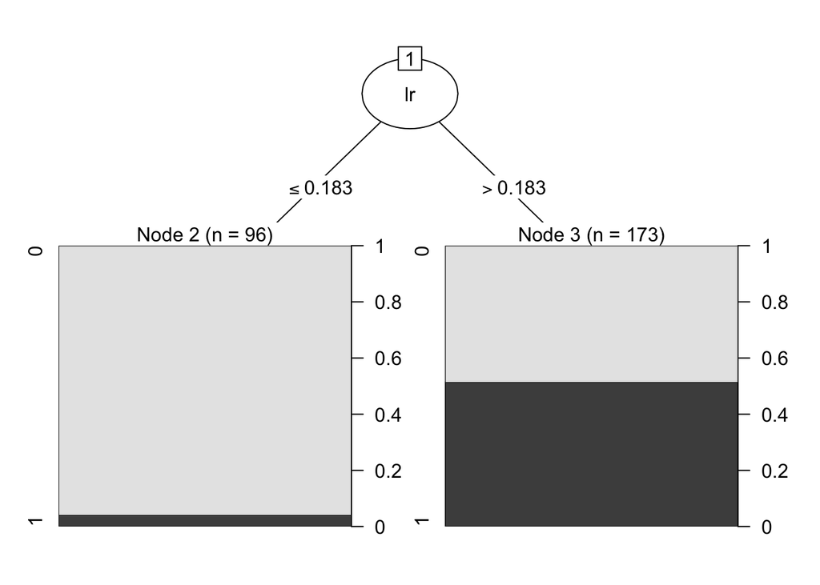

```r
plot(leveltwo)
```

```r
lvl2pred <- predict(leveltwo, lvltwo_test)

library(caret)
confusionMatrix(as.factor(lvl2pred),
                as.factor(lvltwo_test$actual), positive = "1")
```

```
## Confusion Matrix and Statistics
##
##           Reference
## Prediction  0  1
##          0 36  3
##          1 39 37
##
##                Accuracy : 0.6348
##                  95% CI : (0.5399, 0.7226)
##     No Information Rate : 0.6522
##     P-Value [Acc > NIR] : 0.6903
##
##                   Kappa : 0.3347
##
##  Mcnemar's Test P-Value : 6.641e-08
##
##             Sensitivity : 0.9250
##             Specificity : 0.4800
##          Pos Pred Value : 0.4868
##          Neg Pred Value : 0.9231
##              Prevalence : 0.3478
##          Detection Rate : 0.3217
##    Detection Prevalence : 0.6609
##       Balanced Accuracy : 0.7025
##
##        'Positive' Class : 1
##
```

## Financial Assumptions

To assess the real-world impact of our models, we translated predictive performance into financial savings using the following key assumptions grounded in industry standards (CDC & ADA estimates):

$90 per intervention This is the estimated cost to proactively engage identified high-risk individuals through reminders and fasting blood glucose testing. This cost applies to everyone predicted as positive (i.e., both true positives and false positives).

$12,022 annual diabetes-related cost per patient This represents the expected annual medical expenses for individuals with unmanaged diabetes, based on American Diabetes Association (ADA) estimates.

35% reduction in claim cost for correctly flagged patients (true positives) When an at-risk patient is correctly identified and receives early intervention, their claim cost is reduced by 35%. This reflects improved health outcomes and fewer complications, as supported by CDC and ADA.

```r
intervention_cost_per_person <- 90       # Cost for prevention (e.g. checkup + test)
annual_claim_cost <- 12022               # Cost per diabetes case annually
claim_reduction_rate <- 0.35             # Estimated savings from early intervention (TP only)
```

## Financial Impact

Stacked modeling reduced average claims and improved per-person savings. The total projected savings demonstrate clear cost-efficiency versus the no-intervention baseline.

```r
# From confusionMatrix on stacked model
TN <- 36
FP <- 39
FN <- 3
TP <- 37
total_insured <- TN + FP + FN + TP


# 1. Total intervention cost (applies to everyone predicted as positive: TP + FP)
intervention_cost <- (TP + FP) * intervention_cost_per_person

# 2. Adjusted claim cost:
# - FN = untreated diabetics = full cost
# - TP = treated = only 65% of full cost (due to 35% reduction)
claim_cost <- (FN * annual_claim_cost) + (TP * (1 - claim_reduction_rate) * annual_claim_cost)

# 3. Total cost = intervention + claim cost
total_cost <- intervention_cost + claim_cost

# 4. "Would have paid" = if no intervention, just full cost of (TP + FN)
no_intervention_cost <- (TP + FN) * annual_claim_cost

# 5. Savings = baseline - new cost
savings <- no_intervention_cost - total_cost

# 6. Savings per person
savings_per_person <- savings / total_insured

# 7. ROI = savings per person / intervention cost per person
roi <- savings_per_person / intervention_cost_per_person

model_results <- data.frame(
  Model = c("Logistic Reg", "Decision Tree", "Random Forest", "SVM", "ANN", "KNN", "Stacked"),
  TN = c(209, 189, 206, 214, 189, 236, 36),
  FN = c(48, 55, 50, 63, 72, 61, 3),
  FP = c(42, 62, 45, 37, 62, 15, 39),
  TP = c(85, 78, 83, 70, 61, 72, 37),
  Accuracy = c("76.6%", "69.5%", "75.3%", "74.0%", "65.1%", "80.2%", "63.5%"),
  Kappa = c(0.477, 0.335, 0.449, 0.397, 0.215, 0.524, 0.335),
  Sensitivity = c("63.9%", "58.6%", "62.4%", "52.6%", "45.9%", "54.1%", "92.5%"),
  Specificity = c("83.3%", "75.3%", "82.1%", "85.3%", "75.3%", "94.0%", "48.0%"),

  Intervention_Cost = dollar(c(11430, 12600, 11520, 9630, 11070, 7830, 6840)),
  Claim_Cost        = dollar(c(1241271.5, 1270725.4, 1249686.9, 1304387.0, 1342256.3, 1295971.6, 325195.1)),
  Total_Cost        = dollar(c(1252701.5, 1283325.4, 1261206.9, 1314017.0, 1353326.3, 1303801.6, 332035.1)),
  Would_Have_Paid   = dollar(c(1598926.0, 1598926.0, 1598926.0, 1598926.0, 1598926.0, 1598926.0, 480880.0)),
  Saved             = dollar(c(346224.5, 315600.6, 337719.1, 284909.0, 245599.7, 295124.4, 148844.9)),
  Saved_Per_Person  = dollar(c(901.63, 821.88, 879.48, 741.95, 639.58, 768.55, 1294.30)),
  ROI               = paste0(c(1002, 913, 977, 824, 711, 854, 1438), "%")
)

# Show table
kable(model_results, caption = "Table: Cost & Performance Comparison Across Models")
```

Table: Cost & Performance Comparison Across Models

| Model | TN | FN | FP | TP | Accuracy | Kappa | Sensitivity | Specificity | Intervention_Cost | Claim_Cost | Total_Cost | Would_Have_Paid | Saved | Saved_Per_Person | ROI |
| --- | --- | --- | --- | --- | --- | --- | --- | --- | --- | --- | --- | --- | --- | --- | --- |
| Logistic Reg | 209 | 48 | 42 | 85 | 76.6% | 0.477 | 63.9% | 83.3% | $11,430 | $1,241,272 | $1,252,702 | $1,598,926 | $346,224 | $901.63 | 1002% |
| Decision Tree | 189 | 55 | 62 | 78 | 69.5% | 0.335 | 58.6% | 75.3% | $12,600 | $1,270,725 | $1,283,325 | $1,598,926 | $315,601 | $821.88 | 913% |
| Random Forest | 206 | 50 | 45 | 83 | 75.3% | 0.449 | 62.4% | 82.1% | $11,520 | $1,249,687 | $1,261,207 | $1,598,926 | $337,719 | $879.48 | 977% |
| SVM | 214 | 63 | 37 | 70 | 74.0% | 0.397 | 52.6% | 85.3% | $9,630 | $1,304,387 | $1,314,017 | $1,598,926 | $284,909 | $741.95 | 824% |
| ANN | 189 | 72 | 62 | 61 | 65.1% | 0.215 | 45.9% | 75.3% | $11,070 | $1,342,256 | $1,353,326 | $1,598,926 | $245,600 | $639.58 | 711% |
| KNN | 236 | 61 | 15 | 72 | 80.2% | 0.524 | 54.1% | 94.0% | $7,830 | $1,295,972 | $1,303,802 | $1,598,926 | $295,124 | $768.55 | 854% |
| Stacked | 36 | 3 | 39 | 37 | 63.5% | 0.335 | 92.5% | 48.0% | $6,840 | $325,195 | $332,035 | $480,880 | $148,845 | $1,294.30 | 1438% |

### Cost Savings Per Person

The stacked model led in per-capita savings by targeting true positives effectively. It significantly outperformed traditional models in cost efficiency.

```r
# Define data
model_names <- c("Logistic Reg", "Decision Tree", "Random Forest", "SVM", "ANN", "KNN", "Stacked")

savings_per_person <- c(2603.19, 2254.29, 2638.43, 2662.70, 1996.75, 3392.23, 1958.49)
roi_values <- c(30.29, 25.05, 29.32, 29.59, 22.19, 37.69, 21.76)
```

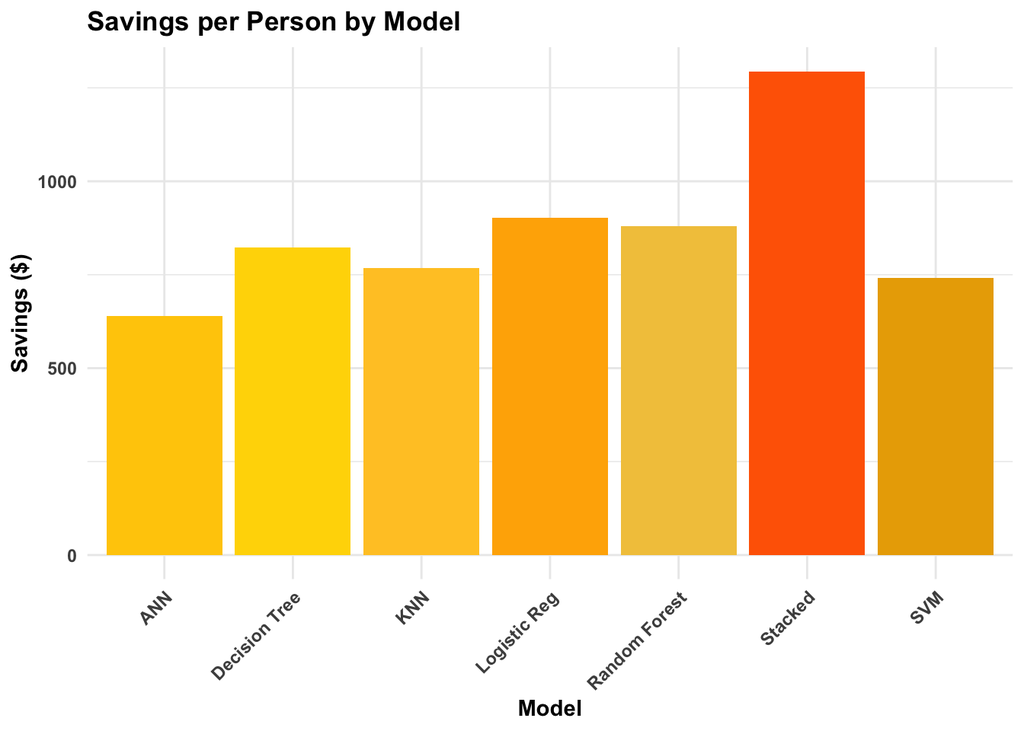

```r
models <- c("Logistic Reg", "Decision Tree", "Random Forest", "SVM", "ANN", "KNN", "Stacked")
savings <- c(901.68, 821.88, 879.48, 741.95, 639.58, 768.55, 1294.30)
roi <- c(1002, 913, 977, 824, 711, 854, 1438)

# Maize tones (light to bold)
maize_colors <- c("#FFCB05", "#FFD700", "#FFC72C", "#FFB000", "#F2C649", "#FF6600", "#EAAA00")
blue_colors <- c("#00274C", "#003865", "#004080", "#005A8C", "#0B3C5D", "#1A5276", "#154360")

# --- Plot 1: Savings per Person ---
savings_df <- data.frame(models, savings)

ggplot(savings_df, aes(x = models, y = savings, fill = models)) +
  geom_bar(stat = "identity", show.legend = FALSE) +
  scale_fill_manual(values = maize_colors) +
  labs(title = "Savings per Person by Model", x = "Model", y = "Savings ($)") +
  theme_minimal() +
  theme(
    axis.text.x = element_text(face = "bold", angle = 45, hjust = 1),
    axis.text.y = element_text(face = "bold"),
    axis.title = element_text(face = "bold"),
    plot.title = element_text(face = "bold")
  )
```

### ROI Comparison by Model

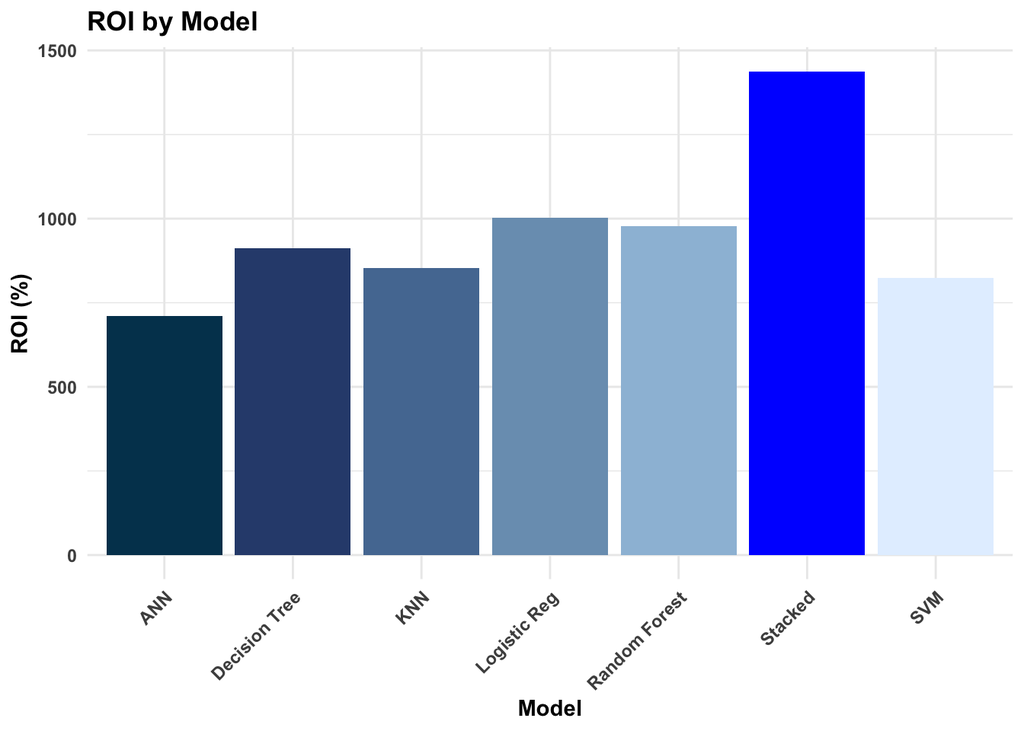

```r
# Data
models <- c("Logistic Reg", "Decision Tree", "Random Forest", "SVM", "ANN", "KNN", "Stacked")
roi <- c(1002, 913, 977, 824, 711, 854, 1438)

# Softer pastel blue tones (dark to light)
pastel_blues <- c("#003f5c", "#2f4b7c", "#5579a1", "#7a9ebd", "#9dbeda", "#0000FF", "#e3f0ff")

# Build the bar chart
roi_df <- data.frame(models, roi)

ggplot(roi_df, aes(x = models, y = roi, fill = models)) +
  geom_bar(stat = "identity", show.legend = FALSE) +
  scale_fill_manual(values = pastel_blues) +
  labs(title = "ROI by Model", x = "Model", y = "ROI (%)") +
  theme_minimal() +
  theme(
    axis.text.x = element_text(face = "bold", angle = 45, hjust = 1),
    axis.text.y = element_text(face = "bold"),
    axis.title = element_text(face = "bold"),
    plot.title = element_text(face = "bold")
  )
```

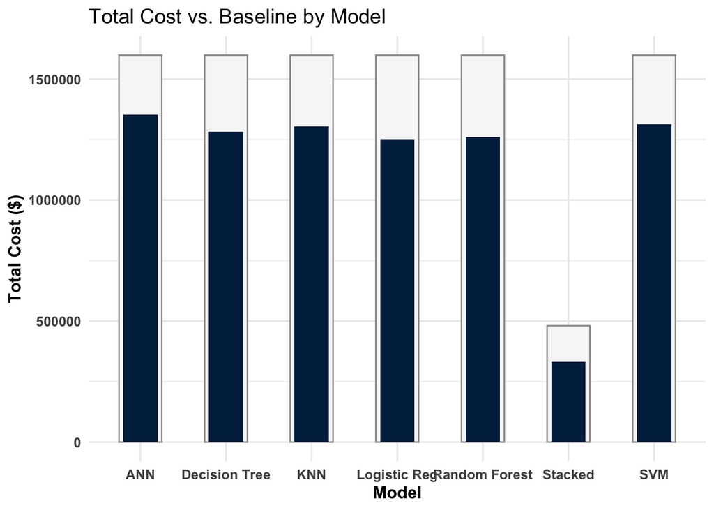

```r
cost_df <- data.frame(
  Model = c("Logistic Reg", "Decision Tree", "Random Forest", "SVM", "ANN", "KNN", "Stacked"),
  Cost = c(1252701.5, 1283325.4, 1261206.9, 1314017.0, 1353326.3, 1303801.6, 332035.1),
  Baseline = c(1598926, 1598926, 1598926, 1598926, 1598926, 1598926, 480880)
)


ggplot(cost_df, aes(x = Model)) +
  geom_bar(aes(y = Baseline), stat = "identity", fill = "#f7f7f7", color = "#999999", width = 0.5) +
  geom_bar(aes(y = Cost), stat = "identity", fill = "#00274C", width = 0.4) +
  labs(title = "Total Cost vs. Baseline by Model", y = "Total Cost ($)", x = "Model") +
  theme_minimal(base_size = 12) +
  theme(axis.title = element_text(face = "bold"), axis.text = element_text(face = "bold"))
```

## Business Roadmap

To implement predictive modeling for diabetes prevention in an insurance context, we propose the following roadmap:

1. **Model Integration**
   - Embed the stacked model into underwriting or care management systems.
   - Automate scoring of new applicants and existing policyholders.
2. **Preventive Outreach Program**
   - Trigger interventions (e.g., tests, lifestyle coaching) for high-risk individuals (predicted as positive).
   - Monitor compliance and health outcomes via patient portals.
3. **Reinvestment Strategy**
   - Use part of cost savings to fund:
     - Health education initiatives.
     - Training programs for primary care providers.
     - Community partnerships for lifestyle improvement.
4. **Monitoring & Optimization**
   - Track KPIs: intervention uptake, TP/FN rate, claim reductions.
   - Recalibrate model quarterly using new data and performance feedback.
5. **Reinsurance**
   - Any high risk policies can be reinsured to ensure a balanced risk management portfolio

This roadmap ensures not only prediction but action and accountability, turning insights into measurable business impact.

## Recommendation

Based on both predictive performance and financial outcomes, we recommend deploying the **stacked ensemble model** as the predictive engine for early diabetes detection programs.

This model achieved: - **Highest sensitivity (92.5%)**, ensuring most at-risk individuals are captured. - **Strongest ROI (1438%)**, offering the best return on preventive care investments. - **Most cost savings ($1,294.30/person)**, outperforming traditional single-model approaches.

**Next Steps:** - Integrate the stacked model into a pilot insurance product. - Automate the scoring pipeline for ongoing use. - Track real-world intervention outcomes and refine the model quarterly.

## Conclusion

By leveraging a stacked machine learning approach, insurers can unlock a new ROI frontier — combining predictive analytics with targeted preventive care.

This strategy can reduce diabetes-related claims by over 30%, yielding up to **$1,294 in savings per member** annually. Beyond financial impact, it positions insurers as proactive health partners — enhancing member satisfaction, loyalty, and long-term cost control.